# RBBS - 2 Visualizations, Part II

Aaron Chafetz 2022-02-28

## RBBS 2 - Visualization, Part II

For our R Building Blocks session today, we will be kicking everything off and giving a quick run down of R and getting a sense of how plotting with in R with the `ggplot` package. This session is modeled after [Chapter 3 of R for Data Science](https://r4ds.had.co.nz/data-visualisation.html).

### Learning Objectives

- Part II
  - Be aware of how data transformation works
  - Know how to apply data transformations
  - Understand how to apply themes and styles

### Setup

For these sessions, we’ll be using RStudio which is an IDE, “Integrated development environment” that makes it easier to work with R. For help on getting setup and installing packages, please reference [this guide](https://usaid-oha-si.github.io/corps/rbbs/2022/01/28/rbbs-0-setup.html).

### Load Packages

```r
library(tidyverse) #install.packages("tidyverse")
```

```r
library(scales) #install.packages("scales")
library(glitr) #remotes::install_github("USAID-OHA-SI/glitr", build_vignettes = TRUE)
```

### Transformation

Last session, we exclusively kept to plotting points, but can do things more sophisticated with the data. For the scatter plots we used, we took the the x and the y values mapped directly from our dataset. We can also used `ggplot` to transform our data, say creating a count or a sum, and displaying the output as a bar chart or histogram.

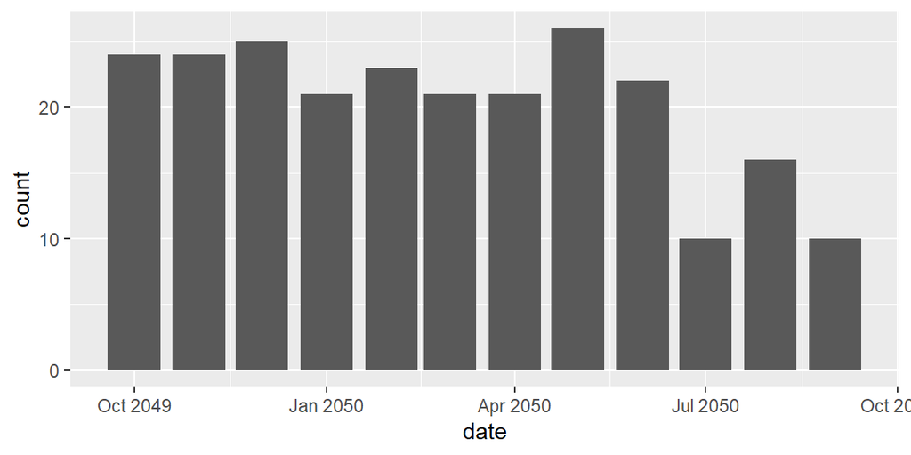

```r
ggplot(data = hfr_mmd) +
  geom_bar(mapping = aes(x = date))
```

By using `geom_bar` we are getting a count of the number of rows that exist in the dataset - in this case collapsing over districts and mechanisms for each date. This could be useful for various purposes, but of more import to us is being able to sum up the total number of patient.

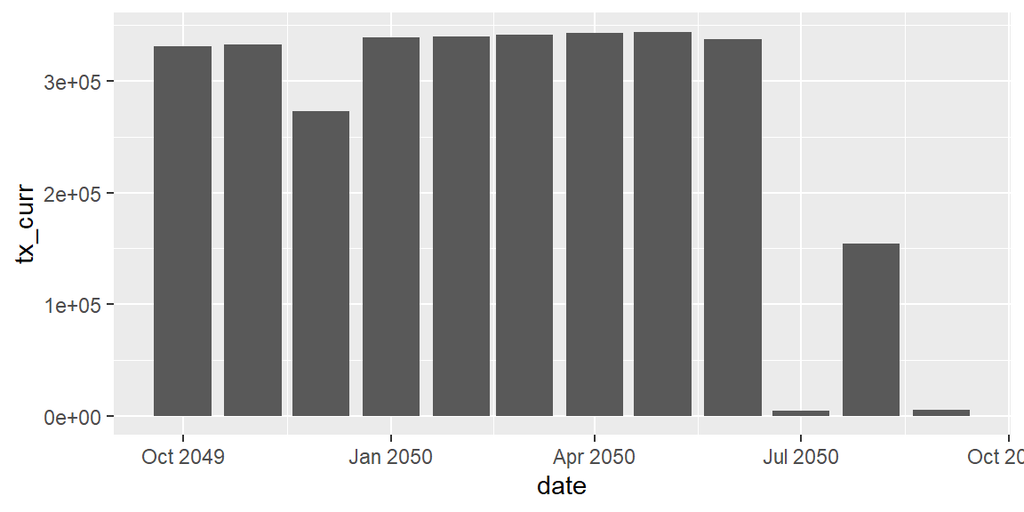

```r
ggplot(data = hfr_mmd) +
  geom_bar(mapping = aes(x = date, y = tx_curr), stat = "identity")
```

A slightly simpler alternative to `geom_bar` is to use `geom_col`, which defaulted to `stat = "identity"` that you would have to otherwise specify to not get a count when using `geom_bar`. The plot below is summing up `tx_curr` over each `date`, aggregating (or collapsing distinctions within) `psnu` and `mech_code`.

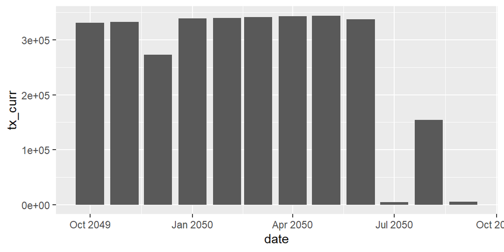

```r
ggplot(data = hfr_mmd) +
  geom_col(mapping = aes(x = date, y = tx_curr))
```

The other nice aspect about using `geom_col` is that is allows us to easily flip our x and y axis.

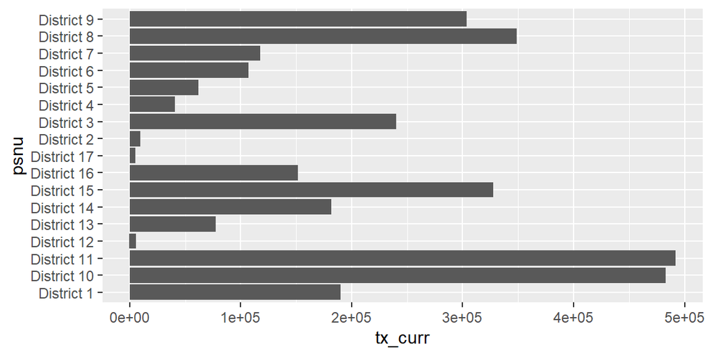

```r
ggplot(data = hfr_mmd) +
  geom_col(mapping = aes(x = tx_curr, y = psnu))
```

We can also quickly transform this into a stacked bar chart by applying a color fill. The fill helps highlight again that `geom_col` is summing up totals across multiple features, like region (`snu1`) in this case/

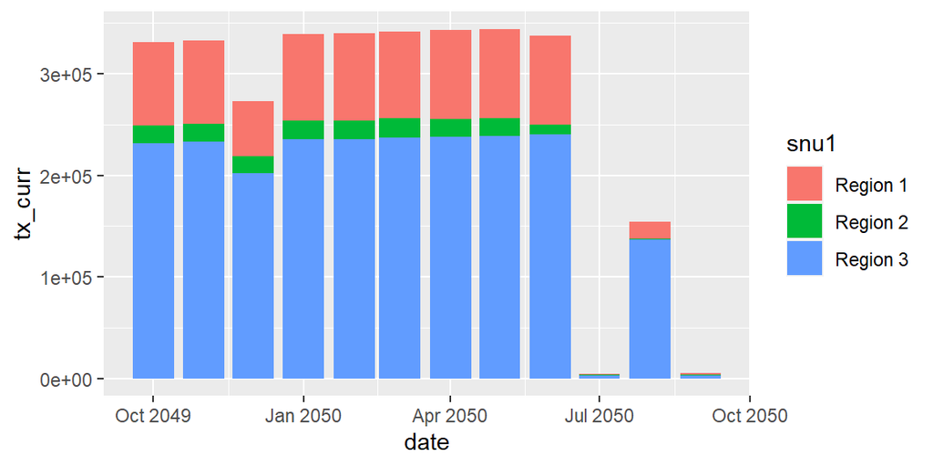

```r
ggplot(data = hfr_mmd) +
  geom_col(mapping = aes(x = date, y = tx_curr, fill = snu1))
```

Stacked bar charts aren’t ideal (we won’t get into principles of data visualization here, but if you’re interested, you can check out [Steve Wexler’s quick talk here](https://www.youtube.com/watch?v=ClMqlGT4V-M)). An alternative would be to create a small multiples plot like we did earlier, which is preferable, but could also just dodge the columns by changing the `position`.

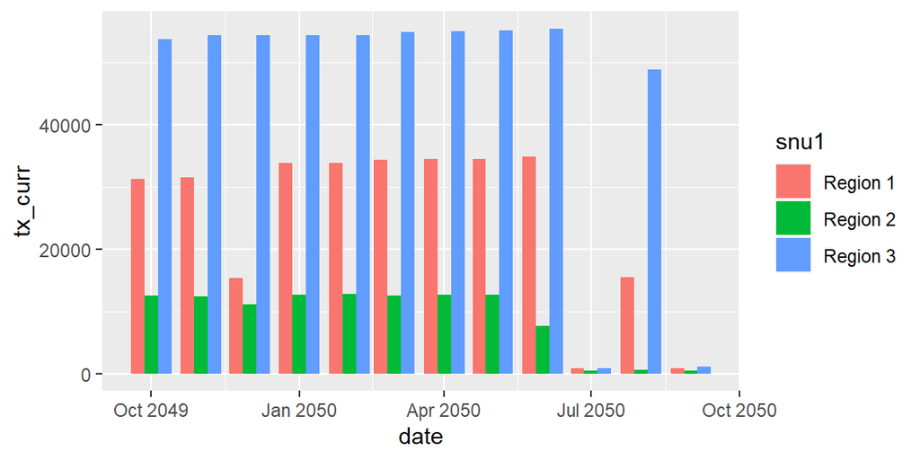

```r
ggplot(data = hfr_mmd) +
  geom_col(mapping = aes(x = date, y = tx_curr, fill = snu1),
           position = "dodge")
```

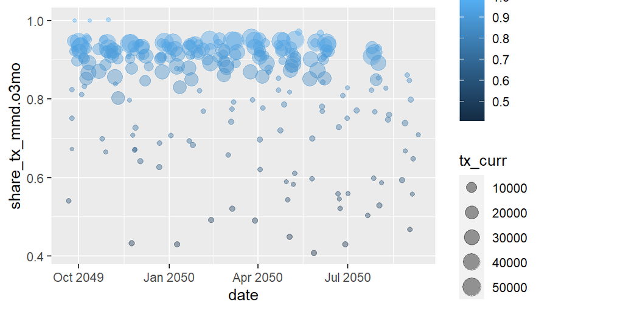

```r
ggplot(data = hfr_mmd) +
  geom_point(mapping = aes(x = date, y = share_tx_mmd.o3mo,
                           color = share_tx_mmd.o3mo, size = tx_curr),
             alpha = .4,
             position = "jitter")
```

You can even refine the radius of the jittering by using a function, `position_jitter()`, allowing us to do a few things like specifying the height and width of the radius of the jitter from the action value as well as to sent a seed so the jitter is not random each time it’s run.

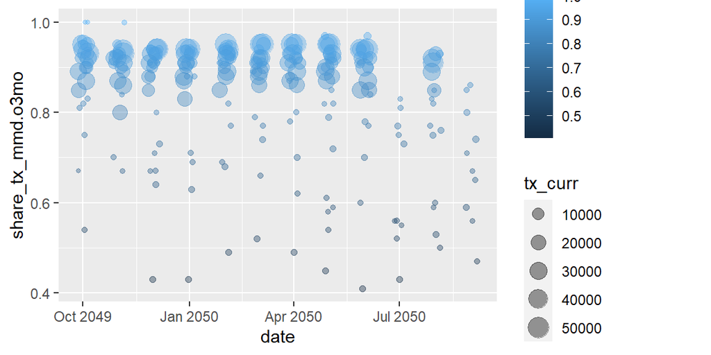

```r
ggplot(data = hfr_mmd) +
  geom_point(mapping = aes(x = date, y = share_tx_mmd.o3mo,
                           color = share_tx_mmd.o3mo, size = tx_curr),
             alpha = .4,
             position = position_jitter(width = 5, height = 0, seed = 42))
```

#### Exercises

1. Using `geom_bar` graph the number of observations for each period (`date`).
2. Plot a bar graph of TX_CURR over time. Rather than using `fill = snu1`, use `color = snu1` in the aesthetics instead. What changes in your plot?

### Additional Thoughts

Before closing the book on the basics of plotting using `ggplot`, I wanted to delve hit on a few things.

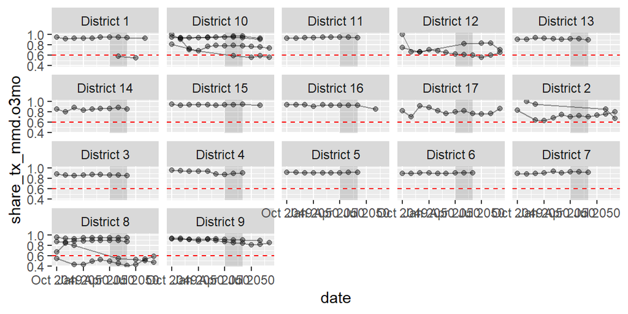

```r
ggplot(data = hfr_mmd,
       mapping = aes(x = date, y = share_tx_mmd.o3mo)) + #global aes to apply to all geom
  annotate(geom = "rect", #type of annotation geometry
           xmin = as.Date("2050-04-01"), #box x coordinates (min)
           xmax = as.Date("2050-06-01"), #box x coordinates (max)
           ymin = -Inf, ymax = Inf, #box y coordinates to run length of plot
           alpha = .2) +
  geom_line(mapping = aes(group = mech_code), #lines need to know how to connect points
            alpha = .4) +
  geom_point(alpha = .4) +
  geom_hline(yintercept = .6, color = "red",
             linetype = "dashed") + #dashed line
  facet_wrap(~psnu)
```

In addition to layer on geoms and facets, we can also clean up the x and y scales as well as adding titles and captions.

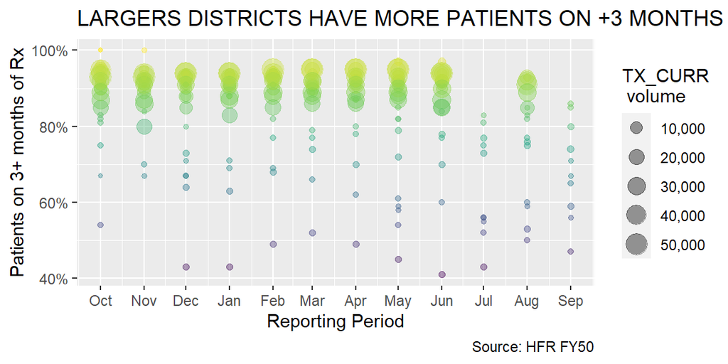

```r
ggplot(data = hfr_mmd) +
  geom_point(mapping = aes(x = date,
                           y = share_tx_mmd.o3mo,
                           color = share_tx_mmd.o3mo,
                           size = tx_curr),
             alpha = .4) +
  scale_x_date(date_breaks = "1 month", #date breaks on x axis
               date_labels = "%b") + #for conversions run ?strptime
  scale_y_continuous(labels = percent) + #in the legend, display values as %
  scale_size(labels = comma) + #apply comma separator to legend
  scale_color_continuous(type = "viridis", #color palette
                         labels = percent, #in the legend, display values as %
                         guide = "none") + #remove legend for color
  labs(x = "Reporting Period",
       y = "Patients on 3+ months of Rx",
       size = "TX_CURR\n volume", #legend title with line break (\n)
       title = "LARGERS DISTRICTS HAVE MORE PATIENTS ON +3 MONTHS OF RX",
       caption = "Source: HFR FY50")
```

We can also start adjusting the style and theme.

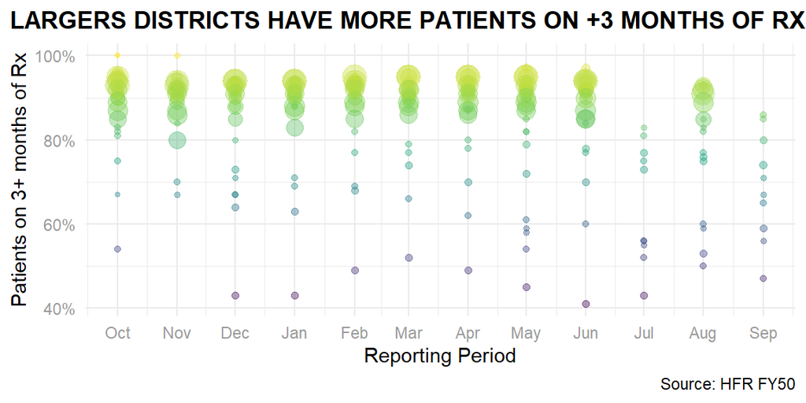

```r
ggplot(data = hfr_mmd) +
  geom_point(mapping = aes(x = date, y = share_tx_mmd.o3mo,
                           color = share_tx_mmd.o3mo, size = tx_curr),
             alpha = .4) +
  scale_x_date(date_breaks = "1 month", date_labels = "%b") +
  scale_y_continuous(labels = percent) +
  scale_size(labels = comma) +
  scale_color_continuous(type = "viridis", labels = percent, guide = "none") +
  labs(x = "Reporting Period",
       y = "Patients on 3+ months of Rx",
       size = "TX_CURR\n volume",
       title = "LARGERS DISTRICTS HAVE MORE PATIENTS ON +3 MONTHS OF RX",
       caption = "Source: HFR FY50") +
  theme_minimal() + #change the plot theme
  theme(legend.position = "none", #no legend
        plot.title.position = "plot", #move the title to right align
        axis.text = element_text(color = "gray60"), #change x/y axis text color
        plot.title = element_text(face = "bold")) #change title to be bold
```

So far we have just been using `glitr` package to access the `hfr_mmd` data, but the package’s function is to apply the [OHA Style Guide](https://issuu.com/achafetz/docs/oha_styleguide) on top of `ggplot`. Since part of the style is a non-standard R font, I am going to load an extra package to load the font. For more information on how to use `extrafont` the first time and install Source Sans Pro, see [this reference](https://usaid-oha-si.github.io/glitr/index.html#what-the-fnt).

```r
library(extrafont) #install.packages("extrafont")
```

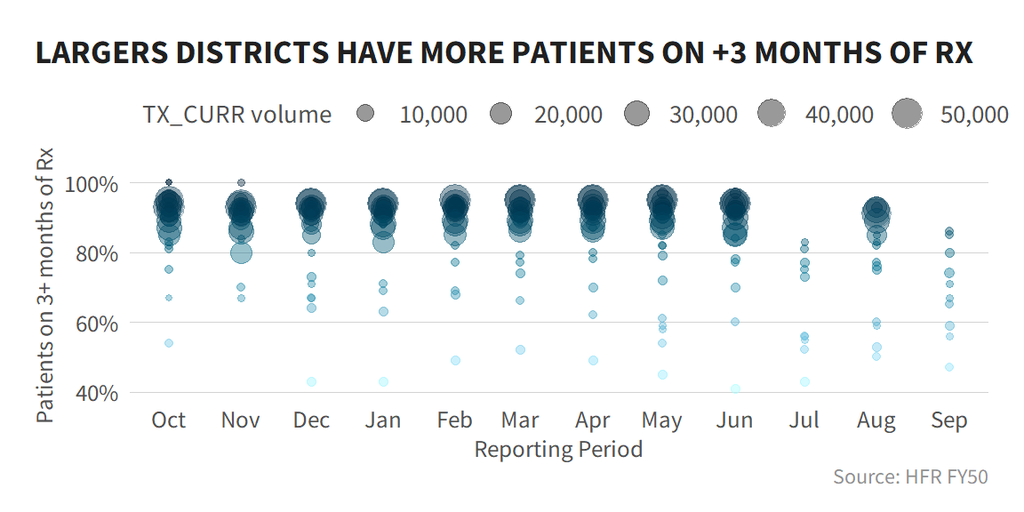

```r
ggplot(data = hfr_mmd) +
  geom_point(mapping = aes(x = date, y = share_tx_mmd.o3mo,
                           color = share_tx_mmd.o3mo, size = tx_curr),
             alpha = .4) +
  scale_x_date(date_breaks = "1 months", date_labels = "%b") +
  scale_y_continuous(labels = percent) +
  scale_size(labels = comma) +
  scale_color_si(palette = "scooters", guide = "none") +
  labs(x = "Reporting Period",
       y = "Patients on 3+ months of Rx",
       size = "TX_CURR volume",
       title = "LARGERS DISTRICTS HAVE MORE PATIENTS ON +3 MONTHS OF RX",
       caption = "Source: HFR FY50") +
  si_style_ygrid()
```

For more information on using the OHA styles and colors in glitr, check out [this guide](https://usaid-oha-si.github.io/glitr/articles/adorn-your-plots.html). And for a good guide on ggplot, see [this cheatsheet](https://raw.githubusercontent.com/rstudio/cheatsheets/main/data-visualization.pdf) from RStudio